# Radiocarbon response to a CO<sub>2</sub> fertilization experiment with fossil carbon

Carlos A. Sierra

2023-10-31

This document contains a set of simulations to predict the radiocarbon response of a tropical ecosystem, representative of the central Amazon, to a continuous application of CO<sub>2</sub> of fossil origin. The main goal is to simulate a CO<sub>2</sub> fertilization experiment analogous to Amazon FACE.

I use here the preliminary version of the carbon model developed for ATTO using the `porce` modeling framework. Therefore, predictions include a reasonable level of uncertainty, which is somehow consistent with the level of variation in carbon stocks and radiocarbon fluxes measured at the terra firme forests in ATTO.

To model radiocarbon dynamics, it is necessary to model the incorporation of atmospheric radiocarbon in the ecosystem during the bomb period. Therefore, the simulations here are split in two steps. In the first step, I first model the incorporation of bomb radiocarbon, from the year 1942 until 2024. In the second step, I add radiocarbon with a signature of -1000 per mil in $\Delta^{14}$C notation. This is equivalent to adding only radiocarbon free CO<sub>2</sub> to the ecosystem. Simulations in this second step are done for two cases, a control case in which only the label is added but there is no increase in GPP, and a second case in which elevated CO<sub>2</sub> induce a 50% increase in GPP relative to the control case. These simulations are run for 10 years, assuming this as the time frame of the experiment.

## Preparations

Let’s first load all required packages, create some color palettes, fire up the cluster and get a mean GPP for the site based on current observations.

```r
library(porce)
library(parallel)
library(SoilR)
library(RColorBrewer)
pal=brewer.pal(7, "Set2")
pal1<-rainbow(n=7, alpha=0.9)
pal2<-rainbow(n=7, alpha=0.5)

no_cores <- detectCores() - 2
cl <- makeCluster(no_cores)

setwd("~/MPIBGC-TEE/porce/simulation/ATTO/")
monthly_gpp<-read.csv("inputs/ATTO_INST_monthlyGPP_2014_2019.csv")
pool_names<-c("Foliage", "Wood", "Fine roots", "Coarse roots", "Fine litter", "CWD", "Soil (0-30 cm)")
GPPmean<- mean(unlist(monthly_gpp[-1])) * 1e-06 * 1e04 *12
GPPsd<- sd(unlist(monthly_gpp[-1])) * 1e-06 * 1e04 *12

set.seed(1033)
atto_gpp<-rnorm(n=nrow(modpars), mean=GPPmean, sd=GPPsd/sqrt(6))
```

We also need to create a time series of atmospheric radiocarbon for the bomb period.

```r
fNHZ3<-read.csv(file="inputs/NHZ3forecast.csv")
NHZ3<-data.frame(Year=c(Hua2021$NHZone3[-(937:939),1], fNHZ3$time),
                 Delta14C=c(Hua2021$NHZone3[-(937:939),2],Delta14C_from_AbsoluteFractionModern(fNHZ3$F14C)))
```

To solve the model over time, we need to specify initial conditions. We assume that the forest is in dynamic equilibrium with respect to carbon. Therefore, we create now a function that takes values of carbon stocks and some parameters from the `porce` region/framework and calculates equilibrium carbon stocks.

```r
pars2stocks<-function(gpp, pars){
  mod<-lam(input=inputGPP(gpp), matrix=makeB(pars))
  equilibriumStock(model=mod)
}
```

We use now this function to compute the initial C stocks for the entire set of parameter values (1000 sets). This is equivalent to obtaining 1000 initial conditions for the carbon stocks. This way we can quantify the uncertainty due to parameter values in the simulations.

```r
allObjects=ls()
clusterExport(cl, varlist=c(allObjects, "lam", "inputGPP", "makeB", "equilibriumStock", "equilibriumOutflux"))

stockList<-clusterMap(cl, fun=pars2stocks, gpp=atto_gpp, pars=asplit(modpars, MARGIN = 1))
stocksATTO<-matrix(unlist(stockList), nrow=7, ncol=1000)
```

Time depend simulations are run in SoilR using the `Model_14` model class. In this case we are not interested in obtaining a time depend solution of the model, but only the predicted values in 2024, which will be used as initial conditions for the second step with the fertilization experiment. The function below returns the radiocarbon content in all pools for a target year, in this case the year 2024.5.

```r
years<-seq(1942,2025, by=1/2)
C14_ty<-function(gpp, pars, targetYear=2024.5){
  Mod<-Model_14(t=years,inputFluxes = inputGPP(gpp),A=makeB(pars), ivList=stocksATTO[,1],
                inputFc=BoundFc(NHZ3, lag=0, format="Delta14C"),
                initialValF=ConstFc(c(-20, -25, -20, -25, -20, -30, -50), format="Delta14C"))
  C14<-getF14(Mod)
  C14[years==targetYear,]
}
```

The computation of these radiocarbon values consumes a significant among of computing resources, so we run them in a cluster and later extract the mean of the 1000 predictions.

```r
allObjects=ls()
clusterExport(cl, varlist=c(allObjects, "getF14", "ConstFc", "Model_14", "BoundFc", "inputGPP", "makeB"))
CS14<-clusterMap(cl,fun=C14_ty, gpp=atto_gpp, pars=asplit(x=modpars, MARGIN=1))
CS14_2024<-matrix(unlist(CS14), ncol=7, nrow=1000, byrow=TRUE)

mCS14<-apply(CS14_2024, MARGIN = 2, mean) # initial condition for experiment
```

## Fertilization experiment

We will run simulations from 2024 until 2034 at monthly time steps. The function below returns a constant value of radiocarbon of -1000 per mil for each time step assuming that all radiocarbon in the air is of fossil origin.

```r
future<-seq(2024.5, 2034.5, by=1/12)
fAtmC14<-sapply(future, function(t) -1000 )
```

The following function computes the radiocarbon response of the ecosystem for any value of gpp, model parameters, and initial C stocks. For the initial radiocarbon values, we use those from the previous step.

```r
fossilResponse<-function(gpp, parms, iniStocks){
  mod<-Model_14(t=future,inputFluxes = inputGPP(gpp),A=makeB(parms), ivList=as.numeric(iniStocks),
                 inputFc=BoundFc(data.frame(future, fAtmC14), lag=0, format="Delta14C"),
                 initialValF=ConstFc(mCS14, format="Delta14C"))
  C14pools<-getF14(mod)
  C14bulk<-getF14C(mod)
  C14resp<-getF14R(mod)
  Ct<-getC(mod)
  Rt<-getReleaseFlux(mod)

  return(list(C14p=C14pools, C14b=C14bulk, C14r=C14resp, Ct=Ct, Rt=Rt))
}
```

We run now all simulations in a cluster for all `modpars` values and initial C stocks. Two simulations are prepared here, one with the average GPP, and another with 1.5 times higher GPP. The last part of the code, compiles the results and aggregates them according to mean and standard deviation.

```r
allObjects=ls()
clusterExport(cl, varlist=c(allObjects, "getF14", "getF14C", "getF14R", "ConstFc", "Model_14", "BoundFc", "inputGPP", "makeB", "getC", "getReleaseFlux"))
ctrl<-clusterMap(cl, fun=fossilResponse, gpp=GPPmean, parms=asplit(modpars, 1), iniStocks = asplit(stocksATTO, 2))

ctrlC14b<-sapply(ctrl, FUN=function(x) x$C14b)
ctrlC14bsts<-data.frame(mean=apply(ctrlC14b, 1, mean), sd=apply(ctrlC14b, 1, sd))
ctrlC14r<-sapply(ctrl, FUN=function(x) x$C14r)
ctrlC14rsts<-data.frame(mean=apply(ctrlC14r, 1, mean), sd=apply(ctrlC14r, 1, sd))
ctrlC14p<-array(unlist(lapply(ctrl, FUN=function(x) x$C14p)), dim=c(121, 7, 1000))
ctrlC14psts<-list(mean=apply(ctrlC14p, c(1,2), mean), sd=apply(ctrlC14p, c(1,2), sd))
ctrlCt<-array(unlist(lapply(ctrl, FUN=function(x) x$Ct)), dim=c(121, 7, 1000))
ctrlCtsts<-list(mean=apply(ctrlCt, c(1,2), mean), sd=apply(ctrlCt, c(1,2), sd))
ctrlRt<-array(unlist(lapply(ctrl, FUN=function(x) x$Rt)), dim=c(121, 7, 1000))
ctrlRtsts<-list(mean=apply(ctrlRt, c(1,2), mean), sd=apply(ctrlRt, c(1,2), sd))


dbl<-clusterMap(cl, fun=fossilResponse, gpp=GPPmean*1.5, parms=asplit(modpars, 1), iniStocks = asplit(stocksATTO, 2))

dblC14b<-sapply(dbl, FUN=function(x) x$C14b)
dblC14bsts<-data.frame(mean=apply(dblC14b, 1, mean), sd=apply(dblC14b, 1, sd))
dblC14r<-sapply(dbl, FUN=function(x) x$C14r)
dblC14rsts<-data.frame(mean=apply(dblC14r, 1, mean), sd=apply(dblC14r, 1, sd))
dblC14p<-array(unlist(lapply(dbl, FUN=function(x) x$C14p)), dim=c(121, 7, 1000))
dblC14psts<-list(mean=apply(dblC14p, c(1,2), mean), sd=apply(dblC14p, c(1,2), sd))
dblCt<-array(unlist(lapply(dbl, FUN=function(x) x$Ct)), dim=c(121, 7, 1000))
dblCtsts<-list(mean=apply(dblCt, c(1,2), mean), sd=apply(dblCt, c(1,2), sd))
dblRt<-array(unlist(lapply(dbl, FUN=function(x) x$Rt)), dim=c(121, 7, 1000))
dblRtsts<-list(mean=apply(dblRt, c(1,2), mean), sd=apply(dblRt, c(1,2), sd))

pol<-function(x, df, cl){
  polygon(c(x, rev(x)), c(df$mean+df$sd, rev(df$mean - df$sd)),
          border=cl, col=cl)
}
```

## Results

The results show that increasing GPP with a fossil radiocarbon signal leads to a faster incorporation of fossil radiocarbon carbon in comparison with the control treatment. The response is faster in the ecosystem respiration flux than in the ecosystem carbon pools. In fact, the respiration flux reaches a quasi-equilibrium with the atmosphere. In contrast, after 10 years of fertilization the ecosystem pools are still responding to the pulse and have not reached isotopic equilibration with the atmosphere.

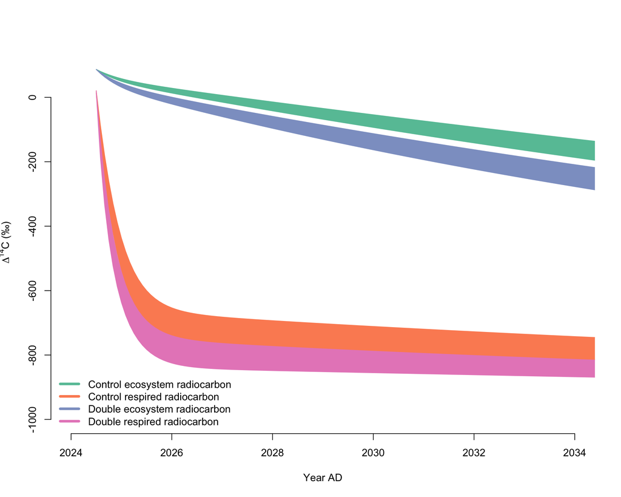

```r
plot(NULL, type="l", xlab="Year AD", ylab=expression(paste(Delta^14, "C (\u2030)")),
     xlim=c(2024, 2034), ylim=c(-1000, 100), bty="n")
pol(future, ctrlC14bsts, pal[1])
pol(future, ctrlC14rsts, pal[2])
pol(future, dblC14bsts, pal[3])
pol(future, dblC14rsts, pal[4])
legend("bottomleft", c("Control ecosystem radiocarbon", "Control respired radiocarbon",
                       "Double ecosystem radiocarbon", "Double respired radiocarbon"), lty=1, lwd=4, col=pal, bty="n")
```

The response of individual pools shows that fertilization with fossil carbon leads to faster incorporation of radiocarbon in all pools (lighter color). However, due to parameter uncertainty, this effect is easier to see in some pools than in others.

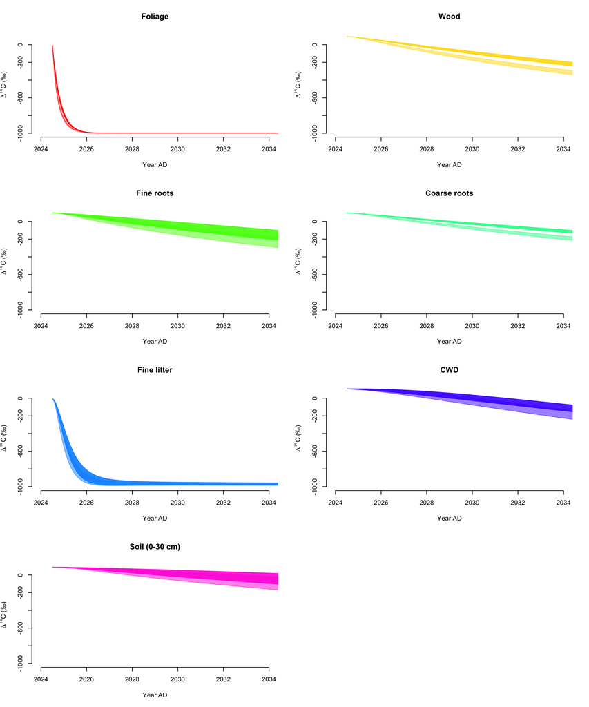

```r
par(mfrow=c(4,2))
for(i in 1:7){
  plot(NULL, type="l", xlab="Year AD", ylab=expression(paste(Delta^14, "C (\u2030)")),
       xlim=c(2024, 2034), ylim=c(-1000, 100), bty="n", main=pool_names[i])
    pol(future, df=data.frame(mean=ctrlC14psts$mean[,i], sd=ctrlC14psts$sd[,i]), cl=pal1[i])
    pol(future, df=data.frame(mean=dblC14psts$mean[,i], sd=dblC14psts$sd[,i]), cl=pal2[i])

}
par(mfrow=c(1,1))
```

The response of individual pools in terms of C stocks also suggest a large degree of variability and responses due to fertilization are difficult to see, except for the carbon stock in foliage and in the fine litter pool.

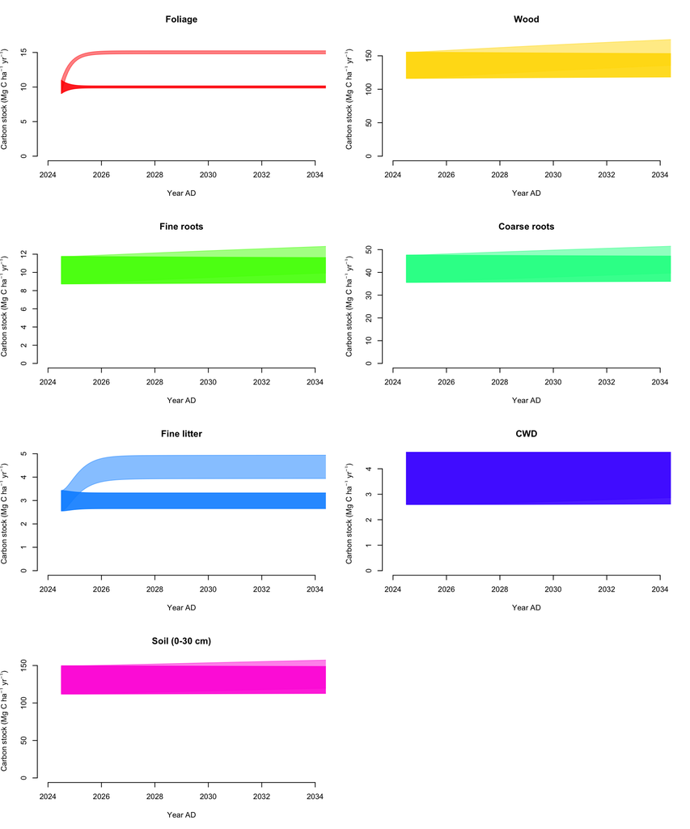

```r
par(mfrow=c(4,2))
for(i in 1:7){
  plot(NULL, type="l", xlab="Year AD", ylab=expression(paste("Carbon stock (Mg C h", a^-1, " y", r^-1, ")")),
       xlim=c(2024, 2034), ylim=c(0, max(dblCtsts$mean[,i])*1.1), bty="n", main=pool_names[i])
  pol(future, df=data.frame(mean=ctrlCtsts$mean[,i], sd=ctrlCtsts$sd[,i]), cl=pal1[i])
  pol(future, df=data.frame(mean=dblCtsts$mean[,i], sd=dblCtsts$sd[,i]), cl=pal2[i])

}
par(mfrow=c(1,1))
```

The total response of the ecosystem in terms of the total stock overlaps significantly with the background variability of the control treatment. If total stocks would be possible to quantify in the field, statistical differences among treatments may not be possible to see for the first 10 years of the experiment.

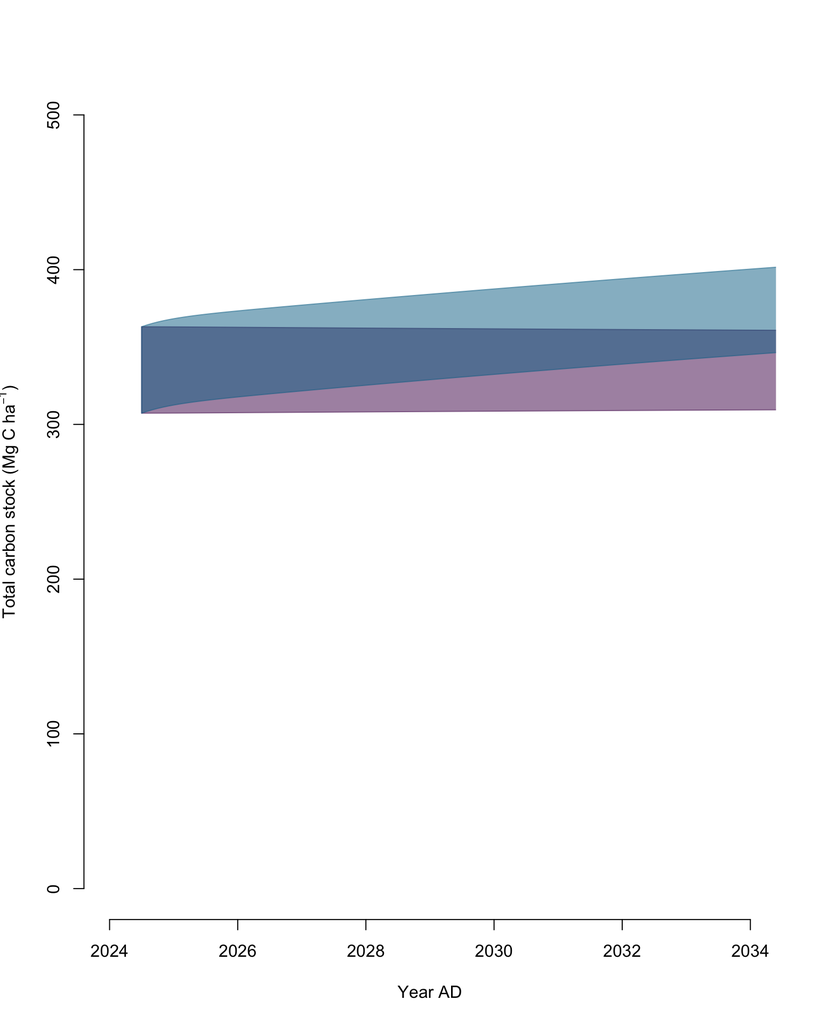

```r
pal3<-hcl.colors(4, alpha=0.5)
plot(NULL, type="l", xlab="Year AD", ylab=expression(paste("Total carbon stock (Mg C h", a^-1, ")")),
     xlim=c(2024, 2034), ylim=c(0, 500), bty="n")
pol(future, df=data.frame(mean=rowSums(ctrlCtsts$mean), sd=sqrt(rowSums(ctrlCtsts$sd^2))), cl=pal3[1])
pol(future, df=data.frame(mean=rowSums(dblCtsts$mean), sd=sqrt(rowSums(dblCtsts$sd^2))), cl=pal3[2])
```

Aboveground biomass carbon is one of the most common measurements in tropical forests. Model predictions also suggests that statistical differences may not be possible to detect in this ecosystem component.

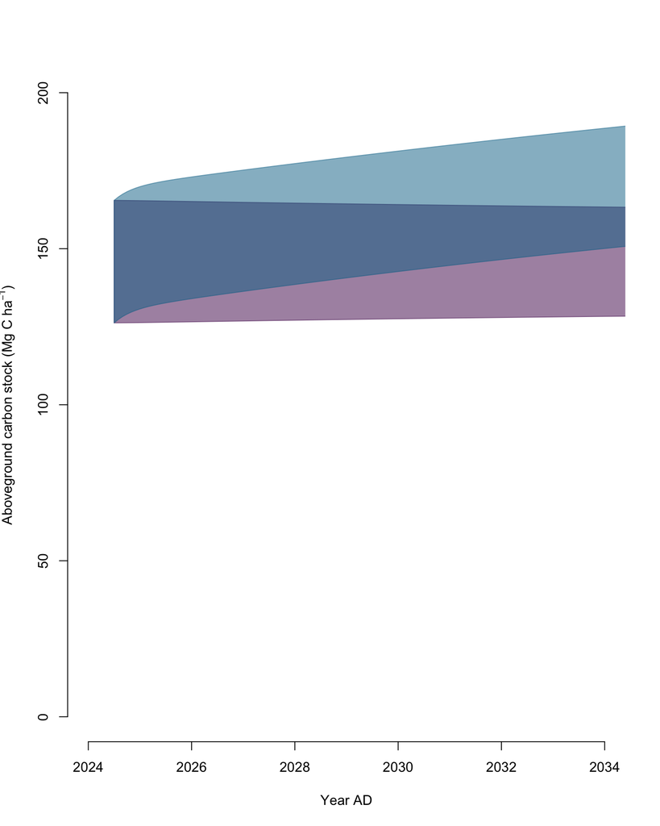

```r
abvg_pools<-match(c("Foliage", "Wood"), table=pool_names)
plot(NULL, type="l", xlab="Year AD", ylab=expression(paste("Aboveground carbon stock (Mg C h", a^-1, ")")),
     xlim=c(2024, 2034), ylim=c(0, 200), bty="n")
pol(future, df=data.frame(mean=rowSums(ctrlCtsts$mean[,abvg_pools]), sd=sqrt(rowSums(ctrlCtsts$sd[,abvg_pools]^2))), cl=pal3[1])
pol(future, df=data.frame(mean=rowSums(dblCtsts$mean[,abvg_pools]), sd=sqrt(rowSums(dblCtsts$sd[,abvg_pools]^2))), cl=pal3[2])
```

The model does predict important differences in terms of ecosystem respiration. This suggest that extra carbon entering through photosynthesis is mostly used for respiration.

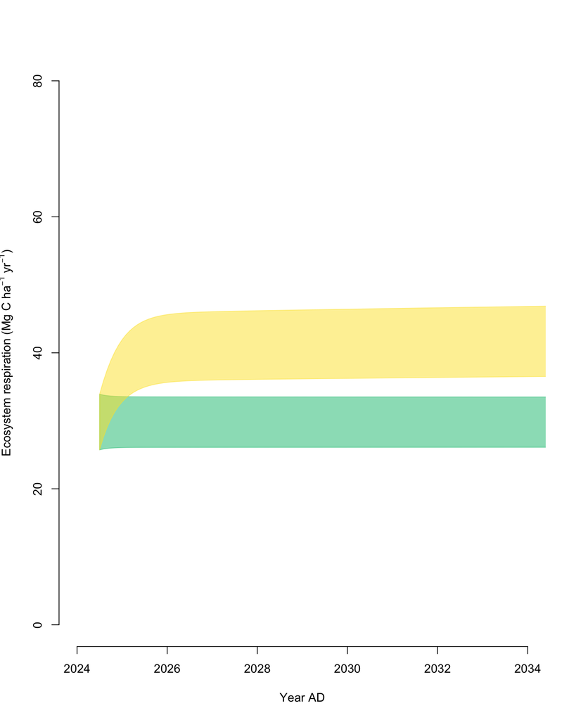

```r
plot(NULL, type="l", xlab="Year AD", ylab=expression(paste("Ecosystem respiration (Mg C h", a^-1, " y", r^-1, ")")),
     xlim=c(2024, 2034), ylim=c(0, 80), bty="n")
pol(future, df=data.frame(mean=rowSums(ctrlRtsts$mean), sd=sqrt(rowSums(ctrlRtsts$sd^2))), cl=pal3[3])
pol(future, df=data.frame(mean=rowSums(dblRtsts$mean), sd=sqrt(rowSums(dblRtsts$sd^2))), cl=pal3[4])
```

In particular, autotrophic respiration is responsible for most of the response.

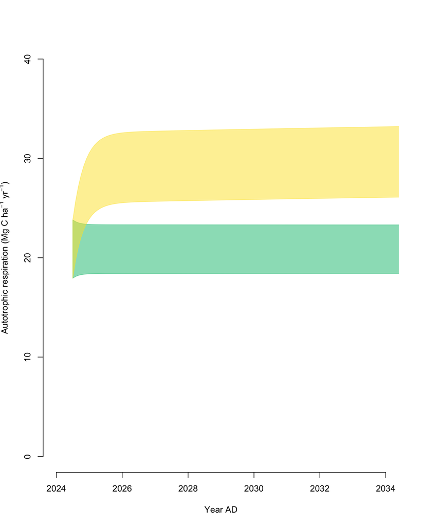

```r
autotroph_pools=match(c("Foliage", "Wood", "Fine roots", "Coarse roots"), table=pool_names)
heterotroph_pools=match(c("Fine litter", "CWD", "Soil (0-30 cm)"), table=pool_names)

plot(NULL, type="l", xlab="Year AD", ylab=expression(paste("Autotrophic respiration (Mg C h", a^-1, " y", r^-1, ")")),
     xlim=c(2024, 2034), ylim=c(0, 40), bty="n")
pol(future, df=data.frame(mean=rowSums(ctrlRtsts$mean[,autotroph_pools]), sd=sqrt(rowSums(ctrlRtsts$sd[,autotroph_pools]^2))), cl=pal3[3])
pol(future, df=data.frame(mean=rowSums(dblRtsts$mean[,autotroph_pools]), sd=sqrt(rowSums(dblRtsts$sd[,autotroph_pools]^2))), cl=pal3[4])
```

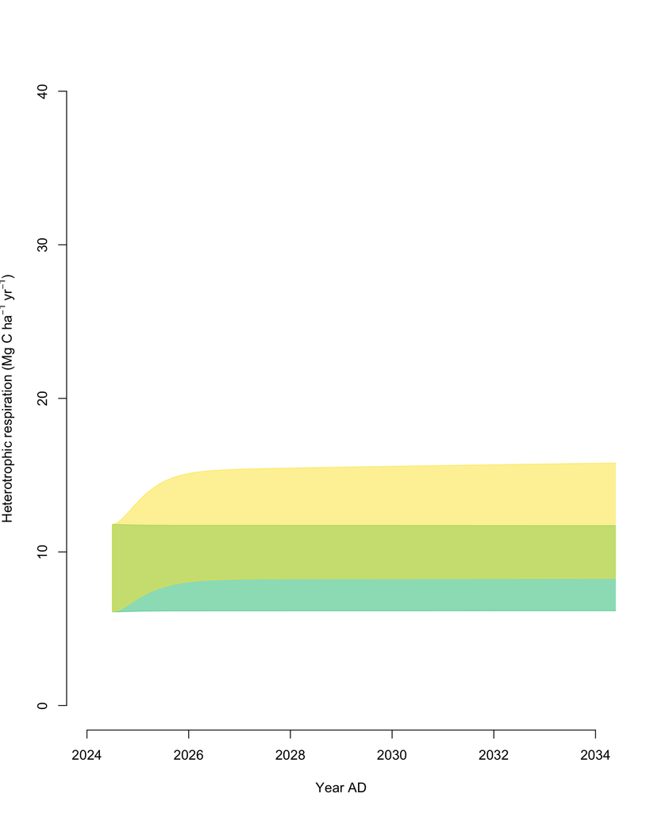

```r
plot(NULL, type="l", xlab="Year AD", ylab=expression(paste("Heterotrophic respiration (Mg C h", a^-1, " y", r^-1, ")")),
     xlim=c(2024, 2034), ylim=c(0, 40), bty="n")
pol(future, df=data.frame(mean=rowSums(ctrlRtsts$mean[,heterotroph_pools]), sd=sqrt(rowSums(ctrlRtsts$sd[,heterotroph_pools]^2))), cl=pal3[3])
pol(future, df=data.frame(mean=rowSums(dblRtsts$mean[,heterotroph_pools]), sd=sqrt(rowSums(dblRtsts$sd[,heterotroph_pools]^2))), cl=pal3[4])
```